# AlphaGenome motif-importance analysis

EVN, SVN, and EVS | held-out chr2 | real genomic backgrounds

# 1 Scope

This report summarizes motif-level interpretation of the final AlphaGenome models trained through chrX. Attribution is calculated across every held-out chr2 test sequence. Region selection uses TF-MoDISco seqlet calling with a 21-bp attribution window and 10-bp flanks on each side (41-bp returned seqlets). The 200 strongest regions are selected with equal representation from the four combinations of class label and attribution sign (50 regions per stratum). Each selected region is compared with four class- and length-matched control windows and evaluated with 20 dinucleotide-shuffle ablations.

HOCOMOCO v14 CORE clustered motifs provide non-redundant labels. Motif labels are the closest TOMTOM matches to attributed regions; they are model-based annotations and do not establish transcription-factor occupancy in vivo.

# 2 Quality control

Analysis and attribution quality control

| Task | Classification | Test sequences | AUROC | Average precision | Attribution method | DeepLIFT relative error | Candidates tested | Important regions | ISM median correlation | ISM correlations below 0.5 |
| --- | --- | --- | --- | --- | --- | --- | --- | --- | --- | --- |
| EVN | Enhancer versus genomic background | 33,260 | 0.907 | 0.910 | saliency | 5.013 | 200 | 0 | 0.836 | 0 |
| SVN | Silencer versus genomic background | 28,258 | 0.903 | 0.905 | saliency | 4.124 | 200 | 150 | 0.844 | 1 |
| EVS | Enhancer versus silencer | 28,582 | 0.648 | 0.630 | saliency | 5.812 | 200 | 98 | 0.776 | 6 |

DeepLIFT failed its summation-to-delta audit for all three AlphaGenome classifiers because the backbone contains operations without valid DeepLIFT rules. The workflow therefore selected saliency automatically. Prediction parity between the wrapped and native model was exact for every task.

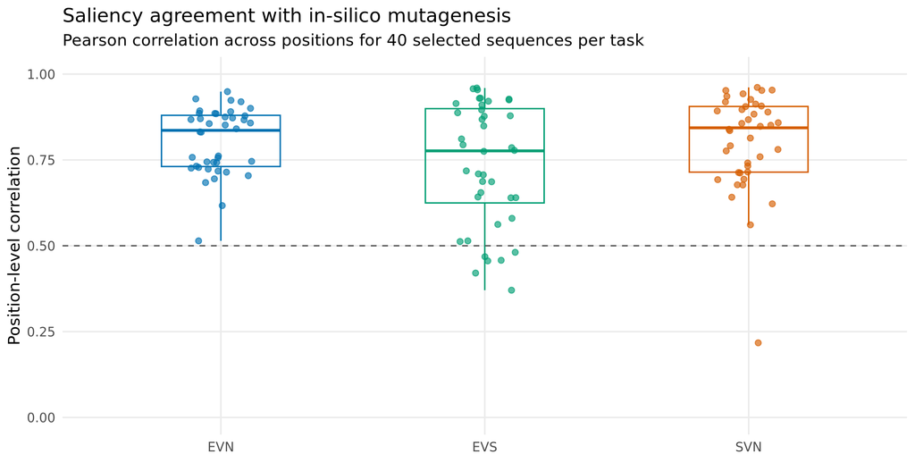

# 3 Candidate design

Balanced candidate panel

| Class | Attribution sign | Regions |
| --- | --- | --- |
| EVN |  |  |
| Negative class | negative | 50 |
| Negative class | positive | 50 |
| Positive class | negative | 50 |
| Positive class | positive | 50 |
| EVS |  |  |
| Negative class | negative | 50 |
| Negative class | positive | 50 |
| Positive class | negative | 50 |
| Positive class | positive | 50 |
| SVN |  |  |
| Negative class | negative | 50 |
| Negative class | positive | 50 |
| Positive class | negative | 50 |
| Positive class | positive | 50 |

All test sequences contribute to the attribution screen. The candidate cap restricts only the expensive perturbation analysis. Consequently, absence from the following tables means “not detected among the strongest tested regions,” not that a model never uses the motif.

# 4 Task-specific causal motif signals

## 4.1 EVN: enhancer versus genomic background

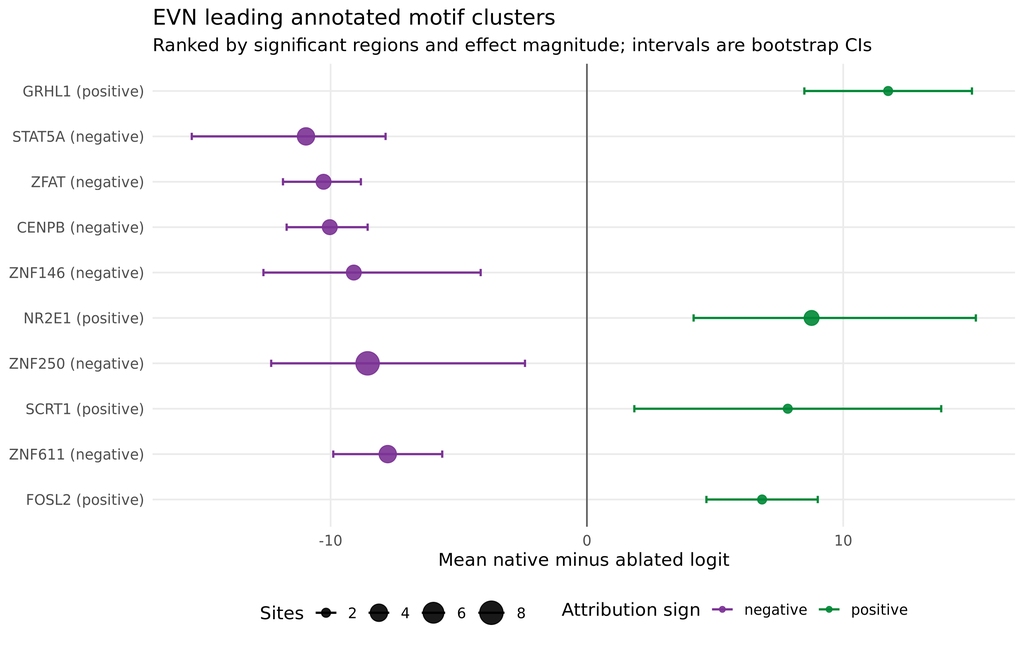

## 4.2 SVN: silencer versus genomic background

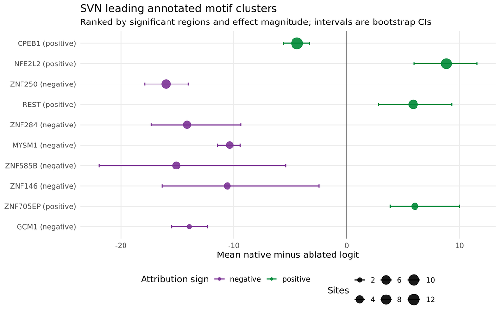

## 4.3 EVS: enhancer versus silencer

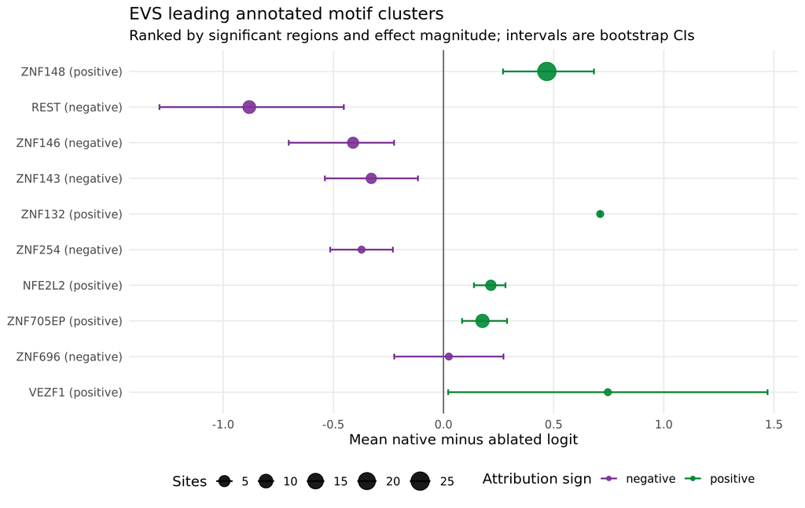

Leading motif clusters by causal-region support

| Motif | Sign | Sites | Important regions | Mean ablation effect | Bootstrap CI | Positive-class sequences | Negative-class sequences |
| --- | --- | --- | --- | --- | --- | --- | --- |
| EVN |  |  |  |  |  |  |  |
| GRHL1 | positive | 2 | 0 | 11.75 | [8.48, 15.02] | 0 | 2 |
| STAT5A | negative | 4 | 0 | −10.96 | [-15.42, -7.85] | 0 | 4 |
| ZFAT | negative | 3 | 0 | −10.27 | [-11.86, -8.82] | 0 | 3 |
| CENPB | negative | 3 | 0 | −10.03 | [-11.72, -8.55] | 0 | 3 |
| ZNF146 | negative | 3 | 0 | −9.09 | [-12.62, -4.14] | 1 | 2 |
| NR2E1 | positive | 3 | 0 | 8.76 | [4.16, 15.17] | 2 | 1 |
| ZNF250 | negative | 8 | 0 | −8.56 | [-12.32, -2.42] | 1 | 7 |
| SCRT1 | positive | 2 | 0 | 7.84 | [1.85, 13.82] | 1 | 1 |
| ZNF611 | negative | 4 | 0 | −7.77 | [-9.90, -5.64] | 0 | 4 |
| FOSL2 | positive | 2 | 0 | 6.83 | [4.66, 9.01] | 2 | 0 |
| EVS |  |  |  |  |  |  |  |
| ZNF148 | positive | 25 | 17 | 0.47 | [0.27, 0.68] | 13 | 12 |
| REST | negative | 8 | 5 | −0.88 | [-1.29, -0.45] | 3 | 5 |
| ZNF146 | negative | 5 | 4 | −0.41 | [-0.70, -0.22] | 4 | 1 |
| ZNF143 | negative | 4 | 3 | −0.33 | [-0.54, -0.12] | 1 | 3 |
| ZNF132 | positive | 2 | 2 | 0.71 | [0.71, 0.71] | 0 | 1 |
| ZNF254 | negative | 2 | 2 | −0.37 | [-0.51, -0.23] | 1 | 1 |
| NFE2L2 | positive | 4 | 2 | 0.22 | [0.14, 0.28] | 1 | 3 |
| ZNF705EP | positive | 9 | 2 | 0.18 | [0.08, 0.29] | 1 | 8 |
| ZNF696 | negative | 2 | 2 | 0.02 | [-0.22, 0.27] | 2 | 0 |
| VEZF1 | positive | 2 | 1 | 0.75 | [0.02, 1.47] | 0 | 2 |
| SVN |  |  |  |  |  |  |  |
| CPEB1 | positive | 13 | 11 | −4.40 | [-5.60, -3.31] | 0 | 13 |
| NFE2L2 | positive | 10 | 8 | 8.83 | [5.95, 11.52] | 9 | 1 |
| ZNF250 | negative | 7 | 7 | −15.99 | [-17.90, -14.01] | 0 | 7 |
| REST | positive | 7 | 6 | 5.89 | [2.84, 9.30] | 6 | 1 |
| ZNF284 | negative | 5 | 4 | −14.14 | [-17.30, -9.38] | 0 | 5 |
| MYSM1 | negative | 4 | 4 | −10.36 | [-11.43, -9.44] | 0 | 4 |
| ZNF585B | negative | 4 | 3 | −15.09 | [-21.93, -5.41] | 1 | 3 |
| ZNF146 | negative | 3 | 3 | −10.57 | [-16.35, -2.44] | 1 | 2 |
| ZNF705EP | positive | 3 | 3 | 6.03 | [3.85, 10.00] | 3 | 0 |
| GCM1 | negative | 2 | 2 | −13.92 | [-15.49, -12.35] | 0 | 1 |

# 5 Descriptive comparison across tasks

The models were trained for different classification problems and are explained on their native held-out data. The comparison below is therefore descriptive: it highlights recurring motif clusters, while effect magnitudes should not be treated as directly calibrated between models.

Motif clusters represented in multiple tasks

| Task | Sign | Sites | Important regions | Mean effect | 95% bootstrap CI |
| --- | --- | --- | --- | --- | --- |
| CENPB |  |  |  |  |  |
| EVN | negative | 3 | 0 | −10.03 | [-11.72, -8.55] |
| SVN | positive | 3 | 0 | 0.82 | [-0.72, 1.80] |
| CPEB1 |  |  |  |  |  |
| EVN | positive | 19 | 0 | −1.16 | [-2.09, -0.20] |
| SVN | positive | 13 | 11 | −4.40 | [-5.60, -3.31] |
| FOSL2 |  |  |  |  |  |
| EVN | positive | 2 | 0 | 6.83 | [4.66, 9.01] |
| SVN | negative | 3 | 1 | 5.29 | [0.92, 13.25] |
| FOXK1 |  |  |  |  |  |
| EVN | negative | 2 | 0 | −0.11 | [-0.59, 0.36] |
| EVS | negative | 2 | 0 | −0.01 | [-0.03, 0.02] |
| NFE2L2 |  |  |  |  |  |
| EVN | positive | 18 | 0 | 6.11 | [4.59, 7.64] |
| EVS | positive | 4 | 2 | 0.22 | [0.14, 0.28] |
| SVN | positive | 10 | 8 | 8.83 | [5.95, 11.52] |
| NR2E1 |  |  |  |  |  |
| EVN | positive | 3 | 0 | 8.76 | [4.16, 15.17] |
| EVS | negative | 2 | 1 | −0.26 | [-0.38, -0.13] |
| REST |  |  |  |  |  |
| EVS | negative | 8 | 5 | −0.88 | [-1.29, -0.45] |
| SVN | positive | 7 | 6 | 5.89 | [2.84, 9.30] |
| TBP |  |  |  |  |  |
| EVN | negative | 2 | 0 | −1.97 | [-7.08, 3.13] |
| SVN | positive | 2 | 2 | −5.60 | [-6.25, -4.94] |
| TSHZ2 |  |  |  |  |  |
| EVS | negative | 2 | 0 | 0.03 | [-0.05, 0.11] |
| SVN | negative | 2 | 1 | 1.17 | [-1.27, 3.62] |
| ZNF146 |  |  |  |  |  |
| EVN | negative | 3 | 0 | −9.09 | [-12.62, -4.14] |
| EVS | negative | 5 | 4 | −0.41 | [-0.70, -0.22] |
| SVN | negative | 3 | 3 | −10.57 | [-16.35, -2.44] |
| ZNF250 |  |  |  |  |  |
| EVN | negative | 8 | 0 | −8.56 | [-12.32, -2.42] |
| SVN | negative | 7 | 7 | −15.99 | [-17.90, -14.01] |
| ZNF254 |  |  |  |  |  |
| EVS | negative | 2 | 2 | −0.37 | [-0.51, -0.23] |
| SVN | negative | 4 | 2 | −8.36 | [-11.67, -3.85] |
| ZNF284 |  |  |  |  |  |
| EVS | negative | 3 | 1 | −0.14 | [-0.42, 0.08] |
| EVS | positive | 2 | 1 | 0.47 | [0.07, 0.88] |
| SVN | negative | 5 | 4 | −14.14 | [-17.30, -9.38] |
| SVN | positive | 2 | 2 | 6.00 | [3.68, 8.33] |
| ZNF362 |  |  |  |  |  |
| EVN | positive | 3 | 0 | 4.45 | [3.08, 5.71] |
| EVS | positive | 2 | 1 | −0.19 | [-0.49, 0.10] |
| ZNF562 |  |  |  |  |  |
| EVS | negative | 2 | 1 | −0.23 | [-0.34, -0.12] |
| SVN | positive | 2 | 2 | −1.89 | [-16.35, 12.57] |
| ZNF585B |  |  |  |  |  |
| EVN | negative | 4 | 0 | −5.35 | [-9.39, -2.69] |
| SVN | negative | 4 | 3 | −15.09 | [-21.93, -5.41] |
| ZNF611 |  |  |  |  |  |
| EVN | negative | 4 | 0 | −7.77 | [-9.90, -5.64] |
| SVN | negative | 6 | 2 | −10.29 | [-13.15, -8.21] |
| ZNF705EP |  |  |  |  |  |
| EVS | positive | 9 | 2 | 0.18 | [0.08, 0.29] |
| SVN | negative | 2 | 0 | −1.50 | [-1.83, -1.18] |
| SVN | positive | 3 | 3 | 6.03 | [3.85, 10.00] |
| ZNF74 |  |  |  |  |  |
| EVN | positive | 2 | 0 | 2.66 | [2.32, 3.01] |
| SVN | negative | 3 | 2 | −3.07 | [-10.99, 7.95] |
| ZNF787 |  |  |  |  |  |
| EVN | negative | 5 | 0 | −0.50 | [-1.85, 0.59] |
| SVN | negative | 4 | 1 | 0.33 | [-1.33, 1.94] |
| ZNF81 |  |  |  |  |  |
| EVS | positive | 2 | 0 | 0.13 | [0.03, 0.23] |
| SVN | negative | 2 | 2 | −4.59 | [-14.72, 5.55] |

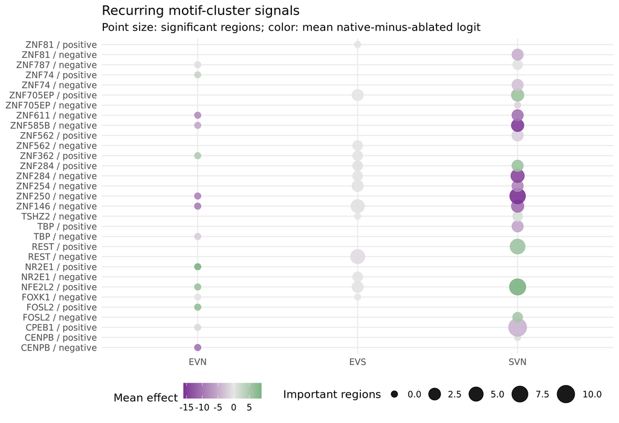

# 6 Class-enriched motif clusters

Class enrichment is calculated only within the balanced, selected candidate panel. It is not a genome-wide motif-enrichment test and is kept separate from the causal ablation result.

Class-enriched clusters within the selected panel

| Motif | Sign | Sites | Important regions | Positive-class sequences | Negative-class sequences | Adjusted enrichment p-value | Mean ablation effect |
| --- | --- | --- | --- | --- | --- | --- | --- |
| EVN |  |  |  |  |  |  |  |
| CPEB1 | positive | 19 | 0 | 0 | 19 | 1.39 × 10<sup>−5</sup> | −1.16 |
| SVN |  |  |  |  |  |  |  |
| CPEB1 | positive | 13 | 11 | 0 | 13 | 1.33 × 10<sup>−3</sup> | −4.40 |

# 7 Interpretation

EVN and SVN provide the strongest basis for biological hypothesis generation because their held-out classification performance and saliency–ISM agreement are high. EVS can still reveal potentially interesting sequence features, but its more modest predictive performance makes those findings exploratory.

Repeated motif families across tasks are candidates for shared regulatory grammar. Task-restricted clusters are candidates for task-specific mechanisms, but their apparent absence elsewhere is conditional on the top-200 candidate design. Ablation estimates how editing a selected region changes the model prediction; the `important region` label additionally requires that effect to exceed matched controls after multiple-testing correction. Neither result establishes TF binding or causal regulation in cells.

# 8 Reproducibility

Analysis provenance

| Item | Value |
| --- | --- |
| Models | Final through-chrX AlphaGenome heads for EVN, SVN, and EVS |
| Evaluation chromosome | chr2 held-out test sets |
| Attribution screen | Saliency over every test sequence |
| Candidate panel | TF-MoDISco seqlet selection; top 50 regions per label × attribution-sign stratum (200/task) |
| Perturbation | 20 dinucleotide-shuffle ablations plus four matched controls per candidate |
| Motif database | HOCOMOCO v14 CORE clustered (648 representative motifs) |
| Motif annotation | Nearest TOMTOM match |
| Random seed | 42 |